# Classification Capstone Project

```python
# Libraries we need
import pandas as pd
import numpy as np
import matplotlib.pyplot as plt
import seaborn as sns

from sklearn.preprocessing import StandardScaler

from sklearn.model_selection import train_test_split

from sklearn.discriminant_analysis import LinearDiscriminantAnalysis
from sklearn.discriminant_analysis import QuadraticDiscriminantAnalysis
from sklearn.linear_model import LogisticRegression
from sklearn.neighbors import KNeighborsClassifier

from sklearn import metrics
from sklearn.metrics import confusion_matrix, classification_report, precision_recall_curve,recall_score
from sklearn import tree
from sklearn.tree import DecisionTreeClassifier
from sklearn.ensemble import BaggingClassifier
from sklearn.ensemble import RandomForestClassifier

from sklearn.model_selection import GridSearchCV
```

```python
df = pd.read_csv("Dataset.csv")
```

```python
df.head()
```

|  | BAD | LOAN | MORTDUE | VALUE | REASON | JOB | YOJ | DEROG | DELINQ | CLAGE | NINQ | CLNO | DEBTINC |
| --- | --- | --- | --- | --- | --- | --- | --- | --- | --- | --- | --- | --- | --- |
| 0 | 1 | 1100 | 25860.0 | 39025.0 | HomeImp | Other | 10.5 | 0.0 | 0.0 | 94.366667 | 1.0 | 9.0 | NaN |
| 1 | 1 | 1300 | 70053.0 | 68400.0 | HomeImp | Other | 7.0 | 0.0 | 2.0 | 121.833333 | 0.0 | 14.0 | NaN |
| 2 | 1 | 1500 | 13500.0 | 16700.0 | HomeImp | Other | 4.0 | 0.0 | 0.0 | 149.466667 | 1.0 | 10.0 | NaN |
| 3 | 1 | 1500 | NaN | NaN | NaN | NaN | NaN | NaN | NaN | NaN | NaN | NaN | NaN |
| 4 | 0 | 1700 | 97800.0 | 112000.0 | HomeImp | Office | 3.0 | 0.0 | 0.0 | 93.333333 | 0.0 | 14.0 | NaN |

```python
df.info()
```

```
<class 'pandas.core.frame.DataFrame'>
RangeIndex: 5960 entries, 0 to 5959
Data columns (total 13 columns):
 #   Column   Non-Null Count  Dtype
---  ------   --------------  -----
 0   BAD      5960 non-null   int64
 1   LOAN     5960 non-null   int64
 2   MORTDUE  5442 non-null   float64
 3   VALUE    5848 non-null   float64
 4   REASON   5708 non-null   object
 5   JOB      5681 non-null   object
 6   YOJ      5445 non-null   float64
 7   DEROG    5252 non-null   float64
 8   DELINQ   5380 non-null   float64
 9   CLAGE    5652 non-null   float64
 10  NINQ     5450 non-null   float64
 11  CLNO     5738 non-null   float64
 12  DEBTINC  4693 non-null   float64
dtypes: float64(9), int64(2), object(2)
memory usage: 605.4+ KB
```

```python
df.nunique()
```

```
BAD           2
LOAN        540
MORTDUE    5053
VALUE      5381
REASON        2
JOB           6
YOJ          99
DEROG        11
DELINQ       14
CLAGE      5314
NINQ         16
CLNO         62
DEBTINC    4693
dtype: int64
```

- Above we can see that Reason and Bad are binary variables
- Nothing needs to be dropped

```python
df.describe()
```

|  | BAD | LOAN | MORTDUE | VALUE | YOJ | DEROG | DELINQ | CLAGE | NINQ | CLNO | DEBTINC |
| --- | --- | --- | --- | --- | --- | --- | --- | --- | --- | --- | --- |
| count | 5960.000000 | 5960.000000 | 5442.000000 | 5848.000000 | 5445.000000 | 5252.000000 | 5380.000000 | 5652.000000 | 5450.000000 | 5738.000000 | 4693.000000 |
| mean | 0.199497 | 18607.969799 | 73760.817200 | 101776.048741 | 8.922268 | 0.254570 | 0.449442 | 179.766275 | 1.186055 | 21.296096 | 33.779915 |
| std | 0.399656 | 11207.480417 | 44457.609458 | 57385.775334 | 7.573982 | 0.846047 | 1.127266 | 85.810092 | 1.728675 | 10.138933 | 8.601746 |
| min | 0.000000 | 1100.000000 | 2063.000000 | 8000.000000 | 0.000000 | 0.000000 | 0.000000 | 0.000000 | 0.000000 | 0.000000 | 0.524499 |
| 25% | 0.000000 | 11100.000000 | 46276.000000 | 66075.500000 | 3.000000 | 0.000000 | 0.000000 | 115.116702 | 0.000000 | 15.000000 | 29.140031 |
| 50% | 0.000000 | 16300.000000 | 65019.000000 | 89235.500000 | 7.000000 | 0.000000 | 0.000000 | 173.466667 | 1.000000 | 20.000000 | 34.818262 |
| 75% | 0.000000 | 23300.000000 | 91488.000000 | 119824.250000 | 13.000000 | 0.000000 | 0.000000 | 231.562278 | 2.000000 | 26.000000 | 39.003141 |
| max | 1.000000 | 89900.000000 | 399550.000000 | 855909.000000 | 41.000000 | 10.000000 | 15.000000 | 1168.233561 | 17.000000 | 71.000000 | 203.312149 |

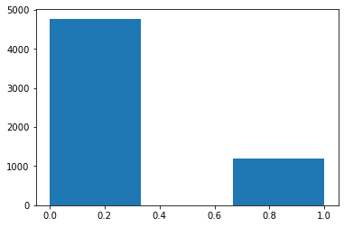

```python
plt.hist(df['BAD'], bins=3)
plt.show()
```

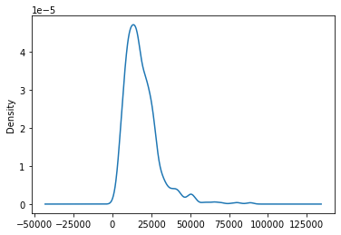

```python
df['LOAN'].plot(kind='density')
plt.show()
```

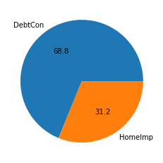

```
DebtCon    3928
HomeImp    1780
Name: REASON, dtype: int64
```

```python
plt.pie(df['REASON'].value_counts(), labels=['DebtCon', 'HomeImp'], autopct='%.1f')
plt.show()
df['REASON'].value_counts()
```

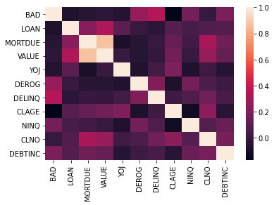

```python
correlation = df.corr()
sns.heatmap(correlation)
plt.show()
```

```python
df['BAD'].value_counts(normalize=True)
```

```
0    0.800503
1    0.199497
Name: BAD, dtype: float64
```

```python
df.fillna(df.mean(), inplace=True)
```

```python
one_hot_encoding = pd.get_dummies(df['REASON'])
df = df.drop('REASON', axis=1)
df = df.join(one_hot_encoding)
df
```

|  | BAD | LOAN | MORTDUE | VALUE | JOB | YOJ | DEROG | DELINQ | CLAGE | NINQ | CLNO | DEBTINC | DebtCon | HomeImp |
| --- | --- | --- | --- | --- | --- | --- | --- | --- | --- | --- | --- | --- | --- | --- |
| 0 | 1 | 1100 | 25860.0000 | 39025.000000 | Other | 10.500000 | 0.00000 | 0.000000 | 94.366667 | 1.000000 | 9.000000 | 33.779915 | 0 | 1 |
| 1 | 1 | 1300 | 70053.0000 | 68400.000000 | Other | 7.000000 | 0.00000 | 2.000000 | 121.833333 | 0.000000 | 14.000000 | 33.779915 | 0 | 1 |
| 2 | 1 | 1500 | 13500.0000 | 16700.000000 | Other | 4.000000 | 0.00000 | 0.000000 | 149.466667 | 1.000000 | 10.000000 | 33.779915 | 0 | 1 |
| 3 | 1 | 1500 | 73760.8172 | 101776.048741 | NaN | 8.922268 | 0.25457 | 0.449442 | 179.766275 | 1.186055 | 21.296096 | 33.779915 | 0 | 0 |
| 4 | 0 | 1700 | 97800.0000 | 112000.000000 | Office | 3.000000 | 0.00000 | 0.000000 | 93.333333 | 0.000000 | 14.000000 | 33.779915 | 0 | 1 |
| ... | ... | ... | ... | ... | ... | ... | ... | ... | ... | ... | ... | ... | ... | ... |
| 5955 | 0 | 88900 | 57264.0000 | 90185.000000 | Other | 16.000000 | 0.00000 | 0.000000 | 221.808718 | 0.000000 | 16.000000 | 36.112347 | 1 | 0 |
| 5956 | 0 | 89000 | 54576.0000 | 92937.000000 | Other | 16.000000 | 0.00000 | 0.000000 | 208.692070 | 0.000000 | 15.000000 | 35.859971 | 1 | 0 |
| 5957 | 0 | 89200 | 54045.0000 | 92924.000000 | Other | 15.000000 | 0.00000 | 0.000000 | 212.279697 | 0.000000 | 15.000000 | 35.556590 | 1 | 0 |
| 5958 | 0 | 89800 | 50370.0000 | 91861.000000 | Other | 14.000000 | 0.00000 | 0.000000 | 213.892709 | 0.000000 | 16.000000 | 34.340882 | 1 | 0 |
| 5959 | 0 | 89900 | 48811.0000 | 88934.000000 | Other | 15.000000 | 0.00000 | 0.000000 | 219.601002 | 0.000000 | 16.000000 | 34.571519 | 1 | 0 |

5960 rows × 14 columns

```python
one_hot_encoding2 = pd.get_dummies(df['JOB'])
df = df.drop('JOB', axis=1)
df = df.join(one_hot_encoding2)
df
```

|  | BAD | LOAN | MORTDUE | VALUE | YOJ | DEROG | DELINQ | CLAGE | NINQ | CLNO | DEBTINC | DebtCon | HomeImp | Mgr | Office | Other | ProfExe | Sales | Self |
| --- | --- | --- | --- | --- | --- | --- | --- | --- | --- | --- | --- | --- | --- | --- | --- | --- | --- | --- | --- |
| 0 | 1 | 1100 | 25860.0000 | 39025.000000 | 10.500000 | 0.00000 | 0.000000 | 94.366667 | 1.000000 | 9.000000 | 33.779915 | 0 | 1 | 0 | 0 | 1 | 0 | 0 | 0 |
| 1 | 1 | 1300 | 70053.0000 | 68400.000000 | 7.000000 | 0.00000 | 2.000000 | 121.833333 | 0.000000 | 14.000000 | 33.779915 | 0 | 1 | 0 | 0 | 1 | 0 | 0 | 0 |
| 2 | 1 | 1500 | 13500.0000 | 16700.000000 | 4.000000 | 0.00000 | 0.000000 | 149.466667 | 1.000000 | 10.000000 | 33.779915 | 0 | 1 | 0 | 0 | 1 | 0 | 0 | 0 |
| 3 | 1 | 1500 | 73760.8172 | 101776.048741 | 8.922268 | 0.25457 | 0.449442 | 179.766275 | 1.186055 | 21.296096 | 33.779915 | 0 | 0 | 0 | 0 | 0 | 0 | 0 | 0 |
| 4 | 0 | 1700 | 97800.0000 | 112000.000000 | 3.000000 | 0.00000 | 0.000000 | 93.333333 | 0.000000 | 14.000000 | 33.779915 | 0 | 1 | 0 | 1 | 0 | 0 | 0 | 0 |
| ... | ... | ... | ... | ... | ... | ... | ... | ... | ... | ... | ... | ... | ... | ... | ... | ... | ... | ... | ... |
| 5955 | 0 | 88900 | 57264.0000 | 90185.000000 | 16.000000 | 0.00000 | 0.000000 | 221.808718 | 0.000000 | 16.000000 | 36.112347 | 1 | 0 | 0 | 0 | 1 | 0 | 0 | 0 |
| 5956 | 0 | 89000 | 54576.0000 | 92937.000000 | 16.000000 | 0.00000 | 0.000000 | 208.692070 | 0.000000 | 15.000000 | 35.859971 | 1 | 0 | 0 | 0 | 1 | 0 | 0 | 0 |
| 5957 | 0 | 89200 | 54045.0000 | 92924.000000 | 15.000000 | 0.00000 | 0.000000 | 212.279697 | 0.000000 | 15.000000 | 35.556590 | 1 | 0 | 0 | 0 | 1 | 0 | 0 | 0 |
| 5958 | 0 | 89800 | 50370.0000 | 91861.000000 | 14.000000 | 0.00000 | 0.000000 | 213.892709 | 0.000000 | 16.000000 | 34.340882 | 1 | 0 | 0 | 0 | 1 | 0 | 0 | 0 |
| 5959 | 0 | 89900 | 48811.0000 | 88934.000000 | 15.000000 | 0.00000 | 0.000000 | 219.601002 | 0.000000 | 16.000000 | 34.571519 | 1 | 0 | 0 | 0 | 1 | 0 | 0 | 0 |

5960 rows × 19 columns

```python
dependent = df['BAD']
independent = df.drop(['BAD'], axis=1)
x_train, x_test, y_train, y_test = train_test_split(independent, dependent, test_size=0.3, random_state=1)
```

```python
def metrics_score(actual, predicted):
    print(classification_report(actual, predicted))
    cm = confusion_matrix(actual, predicted)
    plt.figure(figsize=(8,5))
    sns.heatmap(cm, annot=True,  fmt='.2f', xticklabels=['Not Default', 'Default'], yticklabels=['Not Default', 'Default'])
    plt.ylabel('Actual')
    plt.xlabel('Predicted')
    plt.show()
```

```python
dtree = DecisionTreeClassifier(class_weight={0:0.20, 1:0.80}, random_state=1)
```

```python
dtree.fit(x_train, y_train)
```

```
DecisionTreeClassifier(class_weight={0: 0.2, 1: 0.8}, random_state=1)
```

```
              precision    recall  f1-score   support

           0       1.00      1.00      1.00      3355
           1       1.00      1.00      1.00       817

    accuracy                           1.00      4172
   macro avg       1.00      1.00      1.00      4172
weighted avg       1.00      1.00      1.00      4172
```

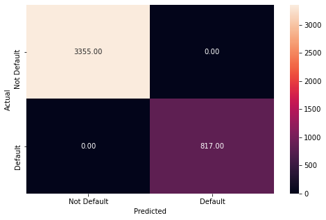

```python
dependent_performance_dt = dtree.predict(x_train)
metrics_score(y_train, dependent_performance_dt)
```

- The above is perfect because we are using the train values, not the test
- Lets test on test data

```
              precision    recall  f1-score   support

           0       0.90      0.92      0.91      1416
           1       0.68      0.61      0.64       372

    accuracy                           0.86      1788
   macro avg       0.79      0.77      0.78      1788
weighted avg       0.85      0.86      0.86      1788
```

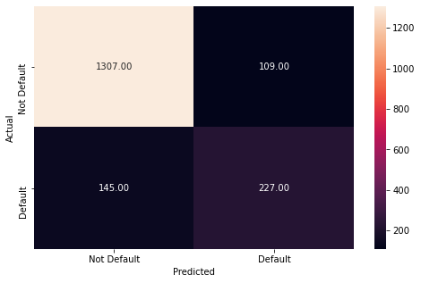

```python
dependent_test_performance_dt = dtree.predict(x_test)
metrics_score(y_test,dependent_test_performance_dt)
```

- As we can see, we got decent performance from this model, lets see if we can do better
- Selfnote: do importance features next

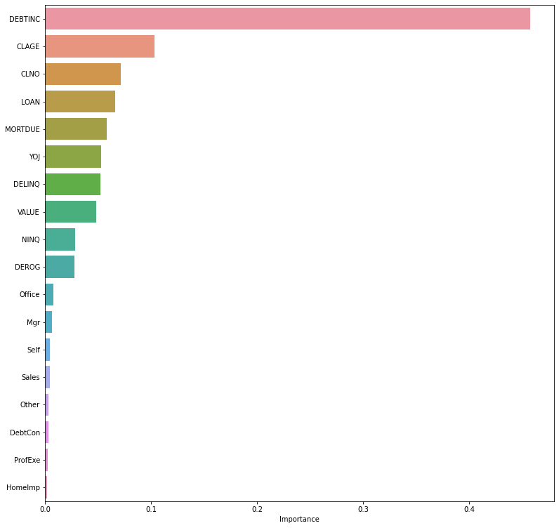

```python
important = dtree.feature_importances_
columns = independent.columns
important_items_df = pd.DataFrame(important, index=columns, columns=['Importance']).sort_values(by='Importance', ascending=False)
plt.figure(figsize=(13,13))
sns.barplot(important_items_df.Importance, important_items_df.index)
plt.show()
```

- I followed this from a previous project to see the most important features
- We can see that the most important features are DEBTINC, CLAGE and CLNO

```python
tree_estimator = DecisionTreeClassifier(class_weight={0:0.20, 1:0.80}, random_state=1)

parameters = {
    'max_depth':np.arange(2,7),
    'criterion':['gini', 'entropy'],
    'min_samples_leaf':[5,10,20,25]
             }
score = metrics.make_scorer(recall_score, pos_label=1)
gridCV= GridSearchCV(tree_estimator, parameters, scoring=score,cv=10)
gridCV = gridCV.fit(x_train, y_train)
tree_estimator = gridCV.best_estimator_
tree_estimator.fit(x_train, y_train)
```

```
DecisionTreeClassifier(class_weight={0: 0.2, 1: 0.8}, max_depth=6,
                       min_samples_leaf=25, random_state=1)
```

```
              precision    recall  f1-score   support

           0       0.95      0.87      0.91      3355
           1       0.60      0.82      0.69       817

    accuracy                           0.86      4172
   macro avg       0.77      0.84      0.80      4172
weighted avg       0.88      0.86      0.86      4172
```

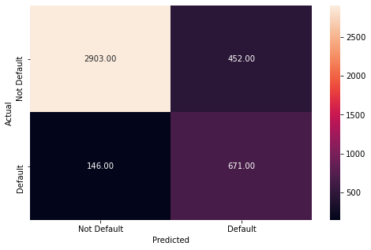

```python
dependent_performance_dt = tree_estimator.predict(x_train)
metrics_score(y_train, dependent_performance_dt)
```

- We increased the less harmful error but decreased the harmful error

```
              precision    recall  f1-score   support

           0       0.94      0.86      0.90      1416
           1       0.60      0.77      0.67       372

    accuracy                           0.84      1788
   macro avg       0.77      0.82      0.79      1788
weighted avg       0.87      0.84      0.85      1788
```

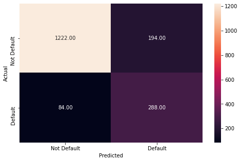

```python
dependent_test_performance_dt = tree_estimator.predict(x_test)
metrics_score(y_test, dependent_test_performance_dt)
```

- Although the performance is slightly worse, we still reduce harmful error

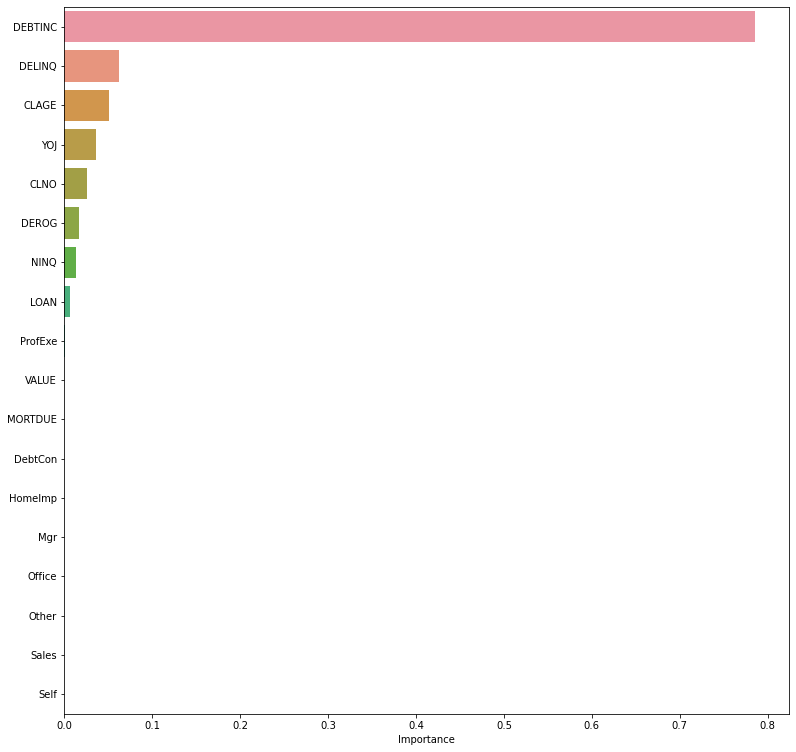

```python
important = tree_estimator.feature_importances_
columns=independent.columns
importance_df=pd.DataFrame(important,index=columns,columns=['Importance']).sort_values(by='Importance',ascending=False)
plt.figure(figsize=(13,13))
sns.barplot(importance_df.Importance,importance_df.index)
plt.show()
```

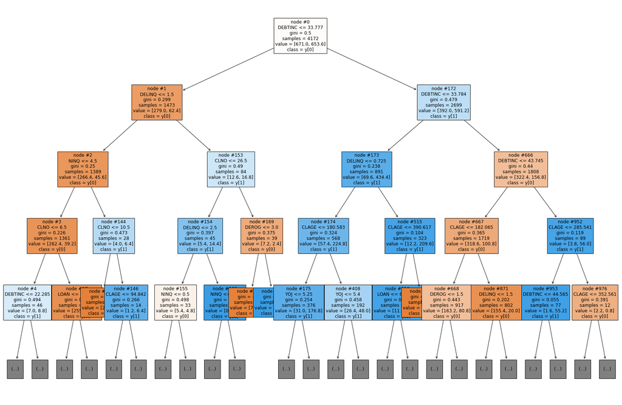

```python
features = list(independent.columns)

plt.figure(figsize=(30,20))

tree.plot_tree(dtree,max_depth=4,feature_names=features,filled=True,fontsize=12,node_ids=True,class_names=True)
plt.show()
```

- A visualization is one of the advantages that dtrees offer, we can show this to the client ot show the thought process

```python
forest_estimator = RandomForestClassifier(class_weight={0:0.20, 1:0.80}, random_state=1)
forest_estimator.fit(x_train, y_train)
```

```
RandomForestClassifier(class_weight={0: 0.2, 1: 0.8}, random_state=1)
```

```
              precision    recall  f1-score   support

           0       1.00      1.00      1.00      3355
           1       1.00      1.00      1.00       817

    accuracy                           1.00      4172
   macro avg       1.00      1.00      1.00      4172
weighted avg       1.00      1.00      1.00      4172
```

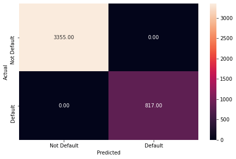

```python
y_predict_training_forest = forest_estimator.predict(x_train)
metrics_score(y_train, y_predict_training_forest)
```

- A perfect classification
  - This implies overfitting

```
              precision    recall  f1-score   support

           0       0.91      0.98      0.95      1416
           1       0.91      0.65      0.76       372

    accuracy                           0.91      1788
   macro avg       0.91      0.82      0.85      1788
weighted avg       0.91      0.91      0.91      1788
```

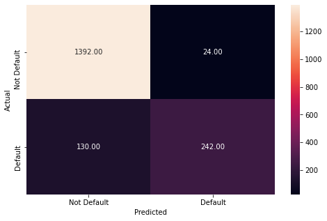

```python
y_predict_test_forest = forest_estimator.predict(x_test)
metrics_score(y_test, y_predict_test_forest)
```

- The performance is a lot better than the original single tree
- Lets fix overfitting

```python
forest_estimator_tuned = RandomForestClassifier(class_weight={0:0.20,1:0.80}, random_state=1)

parameters_rf = {
        "n_estimators": [100,250,500],
        "min_samples_leaf": np.arange(1, 4,1),
        "max_features": [0.7,0.9,'auto'],
}

score = metrics.make_scorer(recall_score, pos_label=1)

# Run the grid search
grid_obj = GridSearchCV(forest_estimator_tuned, parameters_rf, scoring=score, cv=5)
grid_obj = grid_obj.fit(x_train, y_train)

# Set the clf to the best combination of parameters
forest_estimator_tuned = grid_obj.best_estimator_
```

```python
forest_estimator_tuned.fit(x_train, y_train)
```

```
RandomForestClassifier(class_weight={0: 0.2, 1: 0.8}, min_samples_leaf=3,
                       n_estimators=500, random_state=1)
```

```
              precision    recall  f1-score   support

           0       1.00      0.98      0.99      3355
           1       0.93      0.99      0.96       817

    accuracy                           0.98      4172
   macro avg       0.96      0.99      0.97      4172
weighted avg       0.98      0.98      0.98      4172
```

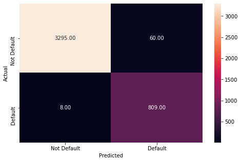

```python
y_predict_train_forest_tuned = forest_estimator_tuned.predict(x_train)
metrics_score(y_train, y_predict_train_forest_tuned)
```

```
              precision    recall  f1-score   support

           0       0.94      0.96      0.95      1416
           1       0.83      0.75      0.79       372

    accuracy                           0.92      1788
   macro avg       0.88      0.86      0.87      1788
weighted avg       0.91      0.92      0.92      1788
```

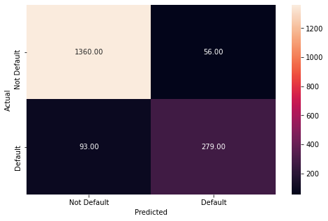

```python
y_predict_test_forest_tuned = forest_estimator_tuned.predict(x_test)
metrics_score(y_test, y_predict_test_forest_tuned)
```

- We now have very good performance
- We can submit this to the company

### Recommendations

- The biggest thing that effects defaulting on a loan is the debt to income ratio. If someone has a lot of debt and a lower income they may have a harder time paying back a loan.
- Something else that effects defaulting on a loan is the number of delinquent credit lines. This means that someone who cannot make their credit card payments will have a hard time paying back a loan.
- Years at job is also a driver of a loans outcome. A large number of years at a job could indicate financial stability.
- DEROG, or a history of delinquent payments is also a warning sign of not being able to pay back a loan.
- Those are some warning signs/good signs that should be looked out for when looking for candidates to give loans to.

I will now apply SHAP to look more into this model.

```python
!pip install shap
import shap
```

```python
shap.initjs()
```

```python
explain = shap.TreeExplainer(forest_estimator_tuned)
shap_vals = explain(x_train)
```

```python
type(shap_vals)
```

```
shap._explanation.Explanation
```

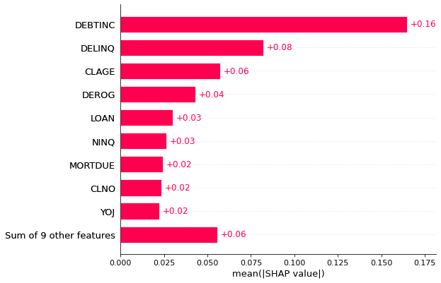

```python
shap.plots.bar(shap_vals[:, :, 0])
```

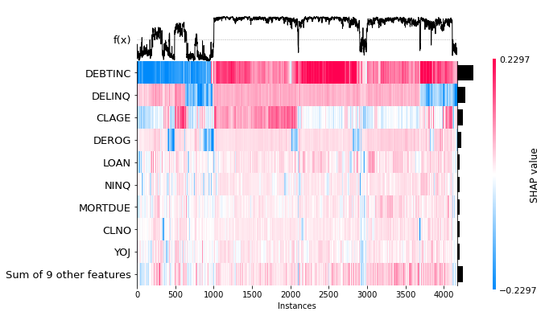

```python
shap.plots.heatmap(shap_vals[:, :, 0])
```

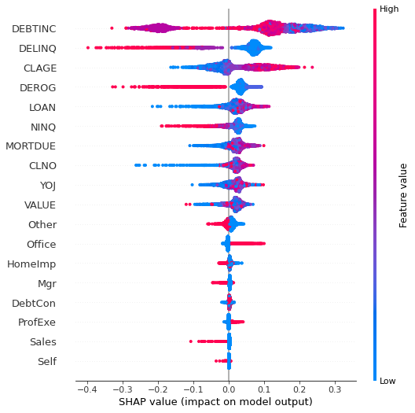

```python
shap.summary_plot(shap_vals[:, :, 0], x_train)
```

```python
print(forest_estimator_tuned.predict(x_test.iloc[107].to_numpy().reshape(1,-1))) # This predicts for one row, 0 means approved, 1 means no.
```

```
[1]
```